# Getting started with the QuakeScope pick catalogues

Machine-learning P and S picks on continuous data, published as Parquet on S3. **No credentials, no database, no account.** Every cell below runs anonymously, on Colab or a laptop, in about ten minutes.

Three catalogues share one bucket, one layout and one schema, so the same reader works for all of them:

| prefix | picker and weights | years | station-locations (with picks) | rows in the Parquet | stored |
| --- | --- | --- | --- | --- | --- |
| `western/` | PhaseNet, `original` weights (Zhu and Beroza, 2019), P and S thresholds 0.2 | 1986 to Sep 2026 | 26,377 (12,981) | 2,130,446,013 (~2.07 B unique) | 55.3 GB |
| `obs/` | PickBlue (Bornstein et al., 2024), PhaseNet architecture, thresholds 0.2 | 1993 to 2026 | 3,036 offshore (2,001) | 104,420,230 (~103.6 M unique) | 2.9 GB |
| `quakescope-2025/` | PhaseNet, `instance` weights, thresholds 0.2: the picks of Ni et al. (2025, *Seismica*) | 2002 to Mar 2025 | 58,403 | 4,376,745,115 | 88.3 GB |

Sources: 2026 rows are the sum of `num_rows` over every Parquet footer, read on 2026-10-13 (`_archive/inventory-20261013/`, also on the [western](https://seisscoped.org/QuakeScope/western_2026.html) and [obs](https://seisscoped.org/QuakeScope/obs_2026.html) report pages); the "unique" estimate is explained in section 2. The 2025 count is the exporter's per-network row count, equal to the retired DocumentDB database's count for all 453 networks (2026-10-14). Stored sizes are an S3 listing of 2026-10-19, which also shows nothing written to `western/` since 2026-10-10 or to `obs/` since 2026-10-09.

This notebook:

1. reads the three station tables and maps them,
2. mirrors one month of one network from `western` and **de-duplicates** it,
3. asks the **availability table** which station-days were read, and which had data but no picks,
4. reads the **same month from the 2025 catalogue** and compares the two pick sets, station-day by station-day and pick by pick,
5. fetches the waveforms from FDSN and draws both catalogues' picks on them,
6. reads a month of **ocean-bottom** picks (the Alaska Amphibious Community Seismic Experiment, AACSE),
7. reads the run records that say which model produced each pick,
8. shows how to read at scale.

For a region and a period, coverage maps and export for PyOcto or GaMMA, continue with `download_the_catalogue.ipynb`. Reference: [`docs/data_access.md`](https://github.com/SeisSCOPED/QuakeScope/blob/main/docs/data_access.md).

### If you pulled picks before October 2026

| change | date | what to do |
| --- | --- | --- |
| Utah, Montana, Arizona, Colorado, New Mexico, BC, Alberta, Baja California and Sonora stations added (`western-fill`, `western-fill2`) | 2026-10-02 | re-sync the networks you use |
| `start_date` / `end_date` are Parquet dates; the old `YYYY.DDD` floats stay as `start_yearday` / `end_yearday` | 2026-09-29 | re-read `stations.parquet` |
| 15.6 M western station-days re-read (`western-reread2`): the reader had chosen one band per station for the whole campaign and skipped days without it; it now picks the best band present each day | 2026-10-06 to 10-09 | re-sync; this is where most new picks are |
| availability table, one row per station-day (`<catalogue>/availability/`) | 2026-10-09 | use it instead of the manifests (section 3) |
| interrupted shard attempts left about 64 M duplicate rows in `western` | measured 2026-10-13 | de-duplicate on `(tid, cha, pha, peak)` (section 2) |
| the 2025 `instance` catalogue converted to the same Parquet layout | 2026-10-14 | section 4 |
| `obs` holds offshore stations only (land stations had come in through reused temporary network codes) | 2026-10-03 | re-sync `obs` |

## 0. Install and set up

Safe to re-run; skip the install if you already have these.

```python
# Colab already has pandas/numpy/matplotlib. These are the rest; installed only if missing.
import importlib.util
missing = [m for m in ("pyarrow", "s3fs", "obspy", "duckdb") if importlib.util.find_spec(m) is None]
if missing:
    %pip install -q {" ".join(missing)}
print("ready" + (f" (installed {', '.join(missing)})" if missing else ""))
```

```
ready
```

```python
import datetime as dt, json, time, urllib.request
from pathlib import Path

import numpy as np
import pandas as pd
import matplotlib.pyplot as plt
import s3fs

BUCKET = "quakescope-picks-2026"
ANON = {"anon": True}               # public-read: no keys, no config, no account
fs = s3fs.S3FileSystem(anon=True)
HTTPS = f"https://{BUCKET}.s3.us-east-2.amazonaws.com"

MIRROR = Path("quakescope_mirror")  # local copy, same layout as the bucket
MIRROR.mkdir(exist_ok=True)

KEY = ["tid", "cha", "pha", "peak"]  # one pick; rows repeating it are duplicates (section 2)
C26, C25, C_OBS = "#2a78d6", "#eb6834", "#1b9e77"
plt.rcParams.update({"figure.dpi": 110, "axes.spines.top": False, "axes.spines.right": False})


def mirror(catalogue, net, year, month):
    # Copy one partition down, skipping files already present. Returns the local directory.
    prefix = f"{catalogue}/picks/network={net}/year={year}/month={month:02d}/"
    local = MIRROR / prefix
    local.mkdir(parents=True, exist_ok=True)
    try:
        remote = fs.ls(f"{BUCKET}/{prefix}", detail=True)
    except FileNotFoundError:
        remote = []
    todo = [o["name"] for o in remote if not (local / Path(o["name"]).name).exists()]
    t0 = time.time()
    if todo:
        fs.get(todo, [str(local / Path(k).name) for k in todo])
    print(f"{prefix}: {len(remote)} files, {sum(o['size'] for o in remote) / 1e6:.0f} MB, "
          f"{len(todo)} fetched in {time.time() - t0:.0f} s")
    return local


def read_picks(local):
    # Read a mirrored partition and drop duplicate rows (same station, band, phase and time).
    df = pd.read_parquet(local)
    n = len(df)
    df = df.drop_duplicates(KEY).reset_index(drop=True)
    print(f"{n:,} rows, {n - len(df):,} duplicates dropped, {len(df):,} picks")
    return df
```

## 1. The station tables

`stations.parquet` is the table each campaign was planned from: every station-location with coordinates, the bands the archive lists, and the operating window. It is the index for choosing what to read.

**Join on `id`**, which equals the picks' `tid` (`NET.STA.LOC`, location code possibly empty: `CI.CLC.`). Take network, station and location from `id.split(".")`: the separate code columns of the 2026 tables still carry CSV-parse damage in places (`1.0` where the location code is `01`; 2,065 western rows on 2026-10-19). `start_date` and `end_date` are Parquet dates in the 2026 tables; a station still operating carries 3000-01-01, not a null.

```python
tables = {c: pd.read_parquet(f"s3://{BUCKET}/{c}/stations.parquet", storage_options=ANON)
          for c in ("western", "obs", "quakescope-2025")}
# The 2025 table keeps the database's "YYYY.DDD" strings (always three digits after the point,
# "2019.227"), so they parse safely; the 2026 tables already hold Parquet dates.
q = tables["quakescope-2025"]
for col in ("start_date", "end_date"):
    q[col] = q[col].map(lambda s: dt.datetime.strptime(s, "%Y.%j").date())   # 3000.001 is beyond pandas timestamps

for c, s in tables.items():
    nets = s.id.str.split(".").str[0]
    print(f"{c:16s} {len(s):6,} station-locations in {nets.nunique():3d} networks")
```

```
western          26,377 station-locations in 154 networks
obs               3,036 station-locations in  76 networks
quakescope-2025  58,403 station-locations in 452 networks
```

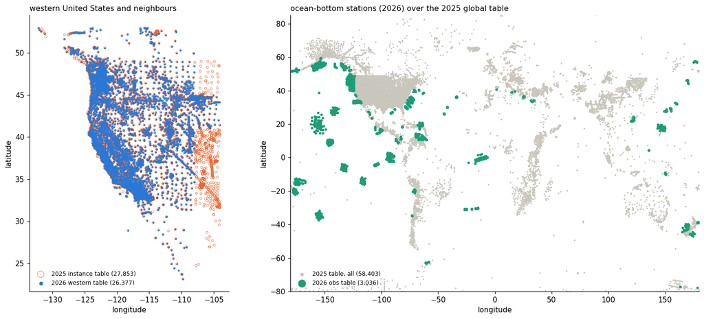

```python
w, o, q = tables["western"], tables["obs"], tables["quakescope-2025"]
box = dict(lon=(w.longitude.min(), w.longitude.max()), lat=(w.latitude.min(), w.latitude.max()))
q_in = q[q.longitude.between(*box["lon"]) & q.latitude.between(*box["lat"]) & (q.elevation > -10)]

fig, ax = plt.subplots(1, 2, figsize=(14, 6.2), gridspec_kw=dict(width_ratios=[1, 1.5]))
ax[0].scatter(q_in.longitude, q_in.latitude, s=9, facecolors="none", edgecolors=C25, lw=0.5,
              label=f"2025 instance table ({len(q_in):,})")
ax[0].scatter(w.longitude, w.latitude, s=2, color=C26, label=f"2026 western table ({len(w):,})")
ax[0].set_aspect(1 / np.cos(np.radians(40)))
ax[0].set_title("western United States and neighbours", loc="left", fontsize=10.5)
ax[0].legend(fontsize=8, markerscale=3, frameon=False, loc="lower left")

ax[1].scatter(q.longitude, q.latitude, s=1, color="#c9c6bd", label=f"2025 table, all ({len(q):,})")
ax[1].scatter(o.longitude, o.latitude, s=6, color=C_OBS, label=f"2026 obs table ({len(o):,})")
ax[1].set_xlim(-180, 180); ax[1].set_ylim(-80, 85)
ax[1].set_title("ocean-bottom stations (2026) over the 2025 global table", loc="left", fontsize=10.5)
ax[1].legend(fontsize=8, markerscale=4, frameon=False, loc="lower left")
for a in ax:
    a.set_xlabel("longitude"); a.set_ylabel("latitude")
fig.tight_layout()
```

The 2025 table is global and lists every location code the metadata ever declared; the 2026 western table covers the western states and their neighbours, including stations whose data start before 2002 (the 2025 run began in 2002, the 2026 run in 1986).

## 2. One month of picks, de-duplicated

The catalogue is Hive-partitioned by **network / year / month**. The fast way to read a partition is to **copy it down, then read it locally**: a month mirrors in seconds and reads in under one, against a minute and a half read straight from S3 file by file.

The example is the Southern California network `CI` in July 2019, the month of the Ridgecrest sequence.

```python
NET, YEAR, MONTH = "CI", 2019, 7
w_local = mirror("western", NET, YEAR, MONTH)
picks = read_picks(w_local)
picks.head()
```

```
western/picks/network=CI/year=2019/month=07/: 338 files, 158 MB, 0 fetched in 0 s
```

```
5,832,752 rows, 76,141 duplicates dropped, 5,756,611 picks
```

|  | tid | cha | pha | start | peak | end | conf | amp | amp_vel | rid |
| --- | --- | --- | --- | --- | --- | --- | --- | --- | --- | --- |
| 0 | CI.CPO. | EH | P | 2019-07-03 00:18:25.270 | 2019-07-03 00:18:25.390 | 2019-07-03 00:18:25.560 | 0.409221 | NaN | 0.000049 | 81932ad1-5feb-4024-97ec-f5c1d9722d0e |
| 1 | CI.CPO. | EH | P | 2019-07-03 00:19:40.270 | 2019-07-03 00:19:40.320 | 2019-07-03 00:19:40.500 | 0.332072 | NaN | 0.000017 | 81932ad1-5feb-4024-97ec-f5c1d9722d0e |
| 2 | CI.CPO. | EH | P | 2019-07-03 00:24:09.250 | 2019-07-03 00:24:09.340 | 2019-07-03 00:24:09.500 | 0.364307 | NaN | 0.000017 | 81932ad1-5feb-4024-97ec-f5c1d9722d0e |
| 3 | CI.CPO. | EH | P | 2019-07-03 00:49:28.490 | 2019-07-03 00:49:28.590 | 2019-07-03 00:49:28.750 | 0.391674 | NaN | 0.000014 | 81932ad1-5feb-4024-97ec-f5c1d9722d0e |
| 4 | CI.CPO. | EH | P | 2019-07-03 01:13:58.830 | 2019-07-03 01:13:58.930 | 2019-07-03 01:13:59.080 | 0.323469 | NaN | 0.000029 | 81932ad1-5feb-4024-97ec-f5c1d9722d0e |

**Why there are duplicates.** Workers ran on Spot capacity. When AWS reclaimed one mid-shard, its partial output stayed in the bucket and the shard was run again from the start, so some picks were written twice, with different run ids (`rid`). The picker is deterministic (re-picking through ObsPy/FDSN on another architecture reproduced 59,298 of 59,315 picks to the millisecond, [western_pick_validation](https://seisscoped.org/QuakeScope/western_pick_validation.html)), so a repeated `(tid, cha, pha, peak)` is the same pick. On 2026-10-13, 12,125 western objects (69.7 M rows) were listed by no manifest; in a sample of 200 of them 92.2 % of rows repeated a pick in a listed object, about 64 M duplicates in all. They will be removed from the bucket; until then, drop them when you read.

### The columns

[output not shown]

`conf` is a detection score, not a probability that the pick is right. 0.2 is deliberately permissive; choose your floor on your own target events. The weights put their scores on different scales, so the same number means different things in the 2025 and 2026 catalogues (section 4).

```python
print(picks.pha.value_counts().to_string(), "\n")
print(f"stations : {picks.tid.nunique():,}")
print(f"bands    : {picks.cha.value_counts().to_dict()}")
print(f"amp      : {picks.amp.notna().mean():.1%} of picks; "
      f"{picks.loc[picks.conf >= 0.5, 'amp'].notna().mean():.1%} of those with conf >= 0.5")
print(f"amp_vel  : {picks.amp_vel.notna().mean():.1%}")
```

```
pha
S    2965943
P    2790668
```

```
stations : 355
```

```
bands    : {'HH': 5449064, 'EH': 210656, 'HN': 96891}
amp      : 44.8% of picks; 96.1% of those with conf >= 0.5
amp_vel  : 99.3%
```

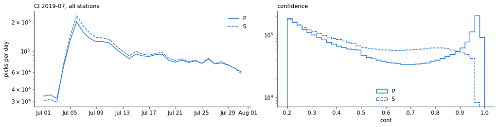

```python
import matplotlib.dates as mdates

fig, ax = plt.subplots(1, 2, figsize=(13, 3.4))
daily = picks.groupby([picks.peak.dt.floor("D"), "pha"]).size().unstack(fill_value=0)
for ph, ls in (("P", "-"), ("S", "--")):
    ax[0].plot(daily.index, daily[ph], ls, lw=1.3, color=C26, label=ph)
ax[0].set_yscale("log"); ax[0].legend(frameon=False); ax[0].set_ylabel("picks per day")
ax[0].xaxis.set_major_formatter(mdates.DateFormatter("%b %d"))
ax[0].set_title(f"{NET} {YEAR}-{MONTH:02d}, all stations", loc="left", fontsize=10.5)
for ph, ls in (("P", "-"), ("S", "--")):
    ax[1].hist(picks.loc[picks.pha == ph, "conf"], bins=np.linspace(0.2, 1, 41), histtype="step",
               ls=ls, lw=1.3, color=C26, label=ph)
ax[1].set_yscale("log"); ax[1].set_xlabel("conf"); ax[1].legend(frameon=False)
ax[1].set_title("confidence", loc="left", fontsize=10.5)
fig.tight_layout()
```

P and S should track each other day by day; a day where one collapses is usually a data outage, not a quiet Earth. The step on July 4 and 6 is the Ridgecrest M6.4 foreshock and M7.1 mainshock.

## 3. Was each station-day read? The availability table

A station-day with no picks can mean three different things: the archive held no data, the data held no arrival above 0.2, or the campaign never read it. `<catalogue>/availability/network=<NET>/availability.parquet` says which, one row per station-day inside each station's operating epochs, built from every job manifest.

| `status` | meaning |
| --- | --- |
| `loaded` | read and picked; `npks` is the pick count, and **`npks` = 0 means data with no arrival above 0.2** |
| `no_data` | the archive listing held nothing that day |
| `not_found` | the archive has no such network-year |
| `empty_read` | an object exists but holds no pickable band (`detail` says what it holds) |
| `unread` | attempted and not read (`detail`: e.g. `too_big`) |
| `unknown` | inside the station's epochs, no record either way (mostly older shards that recorded only what they read, the strong-motion network NP, and networks our account cannot read) |

```python
av = pd.read_parquet(f"s3://{BUCKET}/western/availability/network={NET}/availability.parquet", storage_options=ANON)
av["date"] = pd.to_datetime(av.date)
month = av[(av.date.dt.year == YEAR) & (av.date.dt.month == MONTH)]
print(f"{len(av):,} station-days for {NET} in the table; {len(month):,} in {YEAR}-{MONTH:02d}\n")
print(month.status.value_counts().to_string())
print(f"\nloaded with npks = 0 (data, no picks): {((month.status == 'loaded') & (month.npks == 0)).sum():,}")
```

```
5,340,291 station-days for CI in the table; 19,441 in 2019-07

status
loaded     10764
no_data     8441
unknown      236

loaded with npks = 0 (data, no picks): 319
```

```python
# The table and the Parquet should agree: a loaded station-day with npks > 0 has picks.
got = picks.groupby(["tid", picks.peak.dt.floor("D").rename("date")]).size().rename("n_parquet").reset_index()
loaded = month[month.status == "loaded"]
chk = loaded.merge(got, on=["tid", "date"], how="left").fillna({"n_parquet": 0})
print(f"loaded station-days with npks > 0: {(chk.npks > 0).sum():,}; of those, with picks in the Parquet: "
      f"{((chk.npks > 0) & (chk.n_parquet > 0)).sum():,}")
outside = got.merge(loaded[["tid", "date"]], how="left", indicator=True)
outside = outside[outside["_merge"] == "left_only"]
print(f"picks on station-days the table does not call loaded: {int(outside.n_parquet.sum()):,} "
      f"on {len(outside):,} station-days")

no_picks = month[(month.status == "loaded") & (month.npks == 0)].tid.value_counts()
print(f"\nstations with data but no picks on some days this month: {len(no_picks)}")
print(no_picks.head(8).to_string())
```

```
loaded station-days with npks > 0: 10,445; of those, with picks in the Parquet: 10,445
picks on station-days the table does not call loaded: 17,331 on 24 station-days

stations with data but no picks on some days this month: 77
tid
CI.BTP.       31
CI.CAR.       28
CI.LPC.       20
CI.WBP.       18
CI.COK2.      16
CI.OGC.       15
CI.DSN5.B0    14
CI.DSN5.A0    14
```

Two things to take from the check. Every station-day the table calls `loaded` with `npks` > 0 has picks in the Parquet. The reverse is not quite true: a few station-days the table calls `unknown` do have picks. They come in blocks on the first days of a shard's 20-day window, which is the signature of a shard preempted on Spot and resumed by another worker: the resuming attempt wrote the manifest, so the days the first attempt finished are absent from it (28_resumed_shard_overwrite.md). So: **whether a station-day has picks, ask the Parquet; whether a station-day without picks had data, ask the table.**

## 4. The same month in the 2025 catalogue

`quakescope-2025/` holds the picks of the 2025 run (Ni et al., 2025): PhaseNet with the `instance` weights, 2002 to March 2025, converted from the retired database into this layout. Two differences matter before comparing:

- 2025 picked **every band** a station offered each day, 2026 only the best one. To compare like with like, keep the 2025 picks on the band 2026 used.
- 2025 skipped station-days whose data had more than 150 traces and recorded them with zero picks; the 2026 reader merges fragmented days instead.

```python
q_local = mirror("quakescope-2025", NET, YEAR, MONTH)
p25 = read_picks(q_local)
for df in (picks, p25):
    df["date"] = df.peak.dt.floor("D")

bands = p25.groupby(["tid", "date"]).cha.nunique()
print(f"2025: {len(bands):,} station-days, {(bands > 1).mean():.0%} of them picked on more than one band")

band26 = picks.groupby(["tid", "date"]).cha.first().rename("cha26")
p25 = p25.join(band26, on=["tid", "date"])
same = p25[p25.cha == p25.cha26].copy()      # 2025 picks on the band 2026 used, on station-days both picked
print(f"2025 picks on the 2026 band: {len(same):,} of {len(p25):,}")
print(f"stations: 2026 {picks.tid.nunique()}, 2025 {p25.tid.nunique()}, both {len(set(picks.tid) & set(p25.tid))}")
```

```
quakescope-2025/picks/network=CI/year=2019/month=07/: 10 files, 163 MB, 0 fetched in 0 s
```

```
9,076,874 rows, 0 duplicates dropped, 9,076,874 picks
```

```
2025: 10,558 station-days, 92% of them picked on more than one band
```

```
2025 picks on the 2026 band: 5,020,535 of 9,076,874
```

```
stations: 2026 355, 2025 354, both 353
```

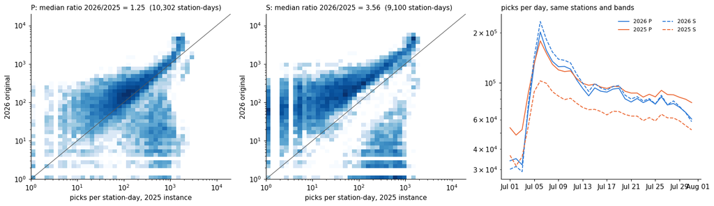

```python
# Station-day by station-day: picks per day in each catalogue, on station-days both picked.
n26 = picks.groupby(["tid", "date", "pha"]).size().rename("n2026")
n25 = same.groupby(["tid", "date", "pha"]).size().rename("n2025")
sd = pd.concat([n26, n25], axis=1).dropna().reset_index()

fig, ax = plt.subplots(1, 3, figsize=(15, 4.4))
edges = np.logspace(0, 4.3, 45)
for a, ph in zip(ax[:2], "PS"):
    g = sd[sd.pha == ph]
    h = a.hist2d(g.n2025, g.n2026, bins=[edges, edges], cmap="Blues", norm=plt.matplotlib.colors.LogNorm())
    a.plot([1, 2e4], [1, 2e4], color="#555", lw=0.8)
    a.set_xscale("log"); a.set_yscale("log")
    a.set_xlabel("picks per station-day, 2025 instance"); a.set_ylabel("2026 original")
    a.set_title(f"{ph}: median ratio 2026/2025 = {np.median(g.n2026 / g.n2025):.2f}  ({len(g):,} station-days)",
                loc="left", fontsize=10)
d26 = picks.groupby(["date", "pha"]).size().unstack(); d25 = same.groupby(["date", "pha"]).size().unstack()
for ph, ls in (("P", "-"), ("S", "--")):
    ax[2].plot(d26.index, d26[ph], ls, color=C26, lw=1.3, label=f"2026 {ph}")
    ax[2].plot(d25.index, d25[ph], ls, color=C25, lw=1.3, label=f"2025 {ph}")
ax[2].set_yscale("log"); ax[2].legend(frameon=False, fontsize=8, ncol=2)
ax[2].xaxis.set_major_formatter(mdates.DateFormatter("%b %d"))
ax[2].set_title("picks per day, same stations and bands", loc="left", fontsize=10)
fig.tight_layout()
```

Pick by pick: match each pick to the nearest pick of the same station and phase in the other catalogue, within 0.5 s. The fraction matched, as a function of the pick's own `conf`, says how much of each catalogue the other one also found; the time differences of matched picks say whether the two weight sets put the arrival in the same place.

```
conf >= 0.2, P: 2026 2,774,569 picks, 42% found in 2025 | 2025 2,966,993 picks, 39% found in 2026
```

```
conf >= 0.2, S: 2026 2,948,305 picks, 29% found in 2025 | 2025 2,053,505 picks, 41% found in 2026
```

```
conf >= 0.5, P: 2026 1,336,977 picks, 64% found in 2025 | 2025 1,082,751 picks, 74% found in 2026
```

```
conf >= 0.5, S: 2026 1,333,048 picks, 50% found in 2025 | 2025   444,813 picks, 81% found in 2026
```

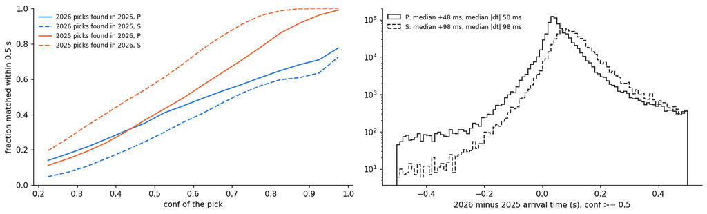

```python
def nearest(a, b, tol_s=0.5):
    # For each pick in a, the signed time to the nearest pick in b (same tid, pha), within tol_s.
    a = a.sort_values("peak"); b = b.sort_values("peak")[["tid", "pha", "peak"]].rename(columns={"peak": "peak_b"})
    m = pd.merge_asof(a, b, left_on="peak", right_on="peak_b", by=["tid", "pha"],
                      direction="nearest", tolerance=pd.Timedelta(seconds=tol_s))
    m["dt"] = (m.peak - m.peak_b).dt.total_seconds()
    return m

common = sd[["tid", "date"]].drop_duplicates()
a26 = picks.merge(common, on=["tid", "date"]); a25 = same.merge(common, on=["tid", "date"])
m26, m25 = nearest(a26, a25), nearest(a25, a26)

fig, ax = plt.subplots(1, 2, figsize=(13, 4))
bins = np.linspace(0.2, 1.0, 17)
for m, c, lab in ((m26, C26, "2026 picks found in 2025"), (m25, C25, "2025 picks found in 2026")):
    for ph, ls in (("P", "-"), ("S", "--")):
        g = m[m.pha == ph]
        frac = g.groupby(pd.cut(g.conf, bins), observed=False).dt.apply(lambda s: s.notna().mean())
        ax[0].plot(0.5 * (bins[1:] + bins[:-1]), frac.values, ls, color=c, lw=1.5, label=f"{lab}, {ph}")
ax[0].set_xlabel("conf of the pick"); ax[0].set_ylabel("fraction matched within 0.5 s"); ax[0].set_ylim(0, 1)
ax[0].legend(frameon=False, fontsize=8)
for ph, ls in (("P", "-"), ("S", "--")):
    g = m26[(m26.pha == ph) & m26.dt.notna() & (m26.conf >= 0.5)]
    ax[1].hist(g.dt, bins=np.linspace(-0.5, 0.5, 101), histtype="step", ls=ls, lw=1.3, color="#333",
               label=f"{ph}: median {g.dt.median() * 1e3:+.0f} ms, median |dt| {g.dt.abs().median() * 1e3:.0f} ms")
ax[1].set_yscale("log"); ax[1].set_xlabel("2026 minus 2025 arrival time (s), conf >= 0.5")
ax[1].legend(frameon=False, fontsize=8)
fig.tight_layout()

for thr in (0.2, 0.5):
    for ph in "PS":
        x = m26[(m26.pha == ph) & (m26.conf >= thr)]; y = m25[(m25.pha == ph) & (m25.conf >= thr)]
        print(f"conf >= {thr}, {ph}: 2026 {len(x):>9,} picks, {x.dt.notna().mean():.0%} found in 2025 | "
              f"2025 {len(y):>9,} picks, {y.dt.notna().mean():.0%} found in 2026")
```

What this month shows, measured when the notebook was built (2026-10-19):

- **S picks are where the two runs differ most.** At `conf` >= 0.5 the 2026 run has about three times as many S picks as 2025 on the same station-days and band, and finds about 80 % of the 2025 S picks; 2025 finds about half of the 2026 ones. This is the `instance` ceiling on dense near-field aftershocks that led us to pick `western` with `original`: no threshold recovers it.
- **The two weight sets do not put the arrival in the same place.** Matched 2026 picks are later than 2025 picks by about 50 ms (P) and 100 ms (S). This is a property of the weights, not of the clocks: against analyst picks, `original` is late by +28 ms (P) and +28 ms (S) at Ridgecrest and +20 / +50 ms at Norcia, while `instance` is early by 10 to 40 ms ([`docs/benchmark/results/timing_full.csv`](https://github.com/SeisSCOPED/QuakeScope/blob/main/docs/benchmark/results/timing_full.csv), median residuals). **Do not mix picks from the two catalogues in one location or tomography run without a per-phase correction.**
- **On single-component short-period stations the difference reverses.** This month of `CI` is almost all `HH`. Across every western station-day picked by both runs from 2002 to March 2025, 2026 has a median of 2 to 3 times the 2025 picks on `HH`, `BH` and `HN`, but 0.06 times on `EH` (5.0 M station-days; `docs/paper_2026/figures/numbers.json`). The `EH` stations of NC, UW, CI, MB and NN are mostly vertical-only. Re-picking two NC `EHZ` station-days locally reproduced both catalogues (23 and 224 picks; 18 and 3,745) and both weight sets recalled the NCEDC analyst picks there; the extra `instance` picks far exceed what the located seismicity supports (3,745 picks on a day with two NCEDC events within 1 degree). Expect far fewer picks on those stations in 2026, and read the 2025 rates on them as mostly noise.
- `conf` is on a different scale in each: 2025 `instance` scores fewer S picks high. A shared threshold is not a shared operating point.

Read the comparison as a statement about this network and month, not about the weights in general: which catalogue finds more depends on the station, the sequence and the threshold, and the benchmark notebooks score both against analyst picks ([benchmark summary](https://seisscoped.org/QuakeScope/benchmark_summary.html)). Matching within 0.5 s is a detection test; 2026 picks absent from 2025 are a mixture of arrivals 2025 missed and false detections 2026 made, and only a reference (analyst picks, or an associated catalogue) can split them.

## 5. Check picks on the waveforms

The catalogues store no waveforms. Fetch them from the SCEDC FDSN service with ObsPy, the same data the picker read, and draw both catalogues' picks on top. The station-minute is the busiest one of confident 2026 picks on the mainshock day, 2019-07-06, among those where the 2025 run also has at least three.

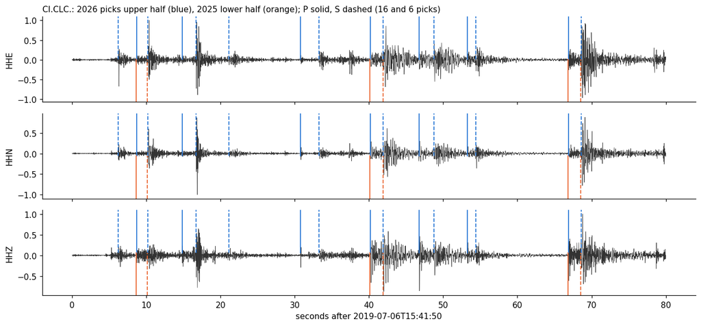

```python
import obspy
from obspy.clients.fdsn import Client

def per_minute(df):
    d = df[(df.conf >= 0.5) & (df.date == pd.Timestamp("2019-07-06"))]
    return d.groupby(["tid", d.peak.dt.floor("min").rename("minute")]).size()
both = pd.concat([per_minute(picks).rename("n26"), per_minute(same).rename("n25")], axis=1).dropna()
tid, minute = both[both.n25 >= 3].n26.idxmax()          # busiest 2026 minute where 2025 also has picks
net, sta, loc = tid.split(".")
band = picks.loc[picks.tid == tid, "cha"].iloc[0]
t0 = obspy.UTCDateTime(minute) - 10
st = Client("SCEDC", timeout=60).get_waveforms(network=net, station=sta, location=loc or "--",
                                               channel=f"{band}?", starttime=t0, endtime=t0 + 80)
st.merge(fill_value="interpolate").detrend("demean").filter("bandpass", freqmin=2, freqmax=20)

win = lambda df: df[(df.tid == tid) & (df.peak >= minute - pd.Timedelta(seconds=10)) & (df.peak < minute + pd.Timedelta(seconds=70))]
w26, w25 = win(picks), win(same)
fig, axes = plt.subplots(len(st), 1, figsize=(12, 1.9 * len(st)), sharex=True)
for ax, tr in zip(np.atleast_1d(axes), st):
    t = tr.times() + (tr.stats.starttime - t0)
    ax.plot(t, tr.data / np.abs(tr.data).max(), lw=0.45, color="#333")
    for df, c, y in ((w26, C26, (0.5, 1)), (w25, C25, (0, 0.5))):
        for _, p in df.iterrows():
            ax.axvline(obspy.UTCDateTime(p.peak) - t0, *y, lw=1.2,
                       ls="-" if p.pha == "P" else "--", color=c)
    ax.set_ylabel(tr.stats.channel)
axes[-1].set_xlabel(f"seconds after {t0.isoformat()}")
axes[0].set_title(f"{tid}: 2026 picks upper half (blue), 2025 lower half (orange); P solid, S dashed "
                  f"({len(w26)} and {len(w25)} picks)", loc="left", fontsize=10)
fig.tight_layout()
```

## 6. Ocean-bottom picks

`obs` holds PickBlue picks on ocean-bottom seismometers, offshore stations only, selected per station by a land mask and a water depth of at least 10 m. The example is AACSE (network `XO`) in August 2018, 67 stations from the Alaska Peninsula to the trench. Its picks were scored against the analyst picks of Barcheck and colleagues: 86 % of analyst P and S arrivals have a PickBlue pick within 1 s ([OBS benchmark](https://seisscoped.org/QuakeScope/phasenet_obs_offshore_benchmark.html)). OBS days often carry only the short-period `EL` band, which is picked for this catalogue alone. This month also shows how much duplication an interrupted shard leaves: about a fifth of the rows repeat a pick.

```
obs/picks/network=XO/year=2018/month=08/: 86 files, 18 MB, 0 fetched in 0 s
```

```
649,789 rows, 135,891 duplicates dropped, 513,898 picks
```

| tid | P | S | days | band | latitude | longitude | depth_m | per_day |
| --- | --- | --- | --- | --- | --- | --- | --- | --- |
| XO.WD54. | 17934 | 27196 | 31 | HH | 56.331433 | -149.066665 | 4520.0 | 1455.806452 |
| XO.LT16. | 32459 | 342 | 31 | HH | 55.491600 | -158.601300 | 125.0 | 1058.096774 |
| XO.LT02. | 13287 | 12424 | 31 | HH | 56.693200 | -153.261100 | 152.0 | 829.387097 |
| XO.LT01. | 12710 | 11443 | 31 | HH | 56.775600 | -152.522800 | 156.0 | 779.129032 |
| XO.LT14. | 21428 | 101 | 31 | HH | 55.699800 | -158.030200 | 125.0 | 694.483871 |
| XO.LT03. | 16090 | 5017 | 31 | HH | 57.866800 | -154.166500 | 202.0 | 680.870968 |
| XO.LT09. | 18528 | 994 | 31 | HH | 55.121500 | -157.138900 | 151.0 | 629.741935 |
| XO.LT20. | 15260 | 2337 | 31 | HH | 54.800200 | -161.374600 | 150.0 | 567.645161 |

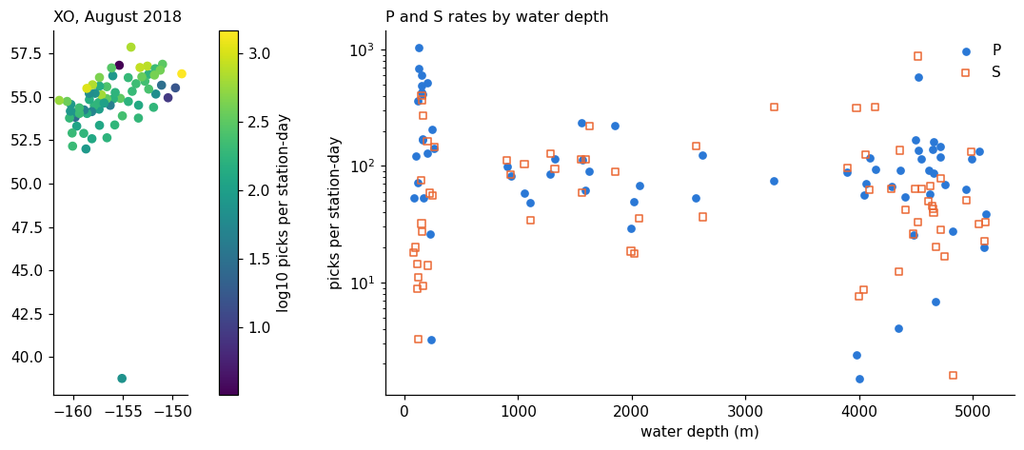

```python
obs = read_picks(mirror("obs", "XO", 2018, 8))
st_o = o.assign(depth_m=-o.elevation)[["id", "latitude", "longitude", "depth_m"]]
per = (obs.groupby("tid").agg(P=("pha", lambda s: (s == "P").sum()), S=("pha", lambda s: (s == "S").sum()),
                              days=("peak", lambda s: s.dt.floor("D").nunique()), band=("cha", "first"))
          .join(st_o.set_index("id")))
per["per_day"] = (per.P + per.S) / per.days

fig, ax = plt.subplots(1, 2, figsize=(13, 4.4))
sc = ax[0].scatter(per.longitude, per.latitude, c=np.log10(per.per_day), s=28, cmap="viridis")
fig.colorbar(sc, ax=ax[0], label="log10 picks per station-day")
ax[0].set_aspect(1 / np.cos(np.radians(55))); ax[0].set_title("XO, August 2018", loc="left", fontsize=10.5)
ax[1].scatter(per.depth_m, per.P / per.days, s=22, color=C26, label="P")
ax[1].scatter(per.depth_m, per.S / per.days, s=22, marker="s", facecolors="none", edgecolors=C25, label="S")
ax[1].set_yscale("log"); ax[1].set_xlabel("water depth (m)"); ax[1].set_ylabel("picks per station-day")
ax[1].legend(frameon=False); ax[1].set_title("P and S rates by water depth", loc="left", fontsize=10.5)
fig.tight_layout()
per.sort_values("per_day", ascending=False).head(8)
```

On the shelf (the `LT` stations, about 150 m of water) S rates scatter over two orders of magnitude and often sit far below P; at the deep stations seaward of the trench, S tracks P. Shelf noise and the sediment layer change what a picker sees; the [OBS benchmark](https://seisscoped.org/QuakeScope/phasenet_obs_offshore_benchmark.html) scores both against analyst picks.

## 7. Provenance

Every pick carries a run id, and the run record names the model, weights, thresholds and library versions. A campaign runs under one configuration but creates a new run id at every worker start, so there are thousands of records that differ only in `run_id` and `created`: quote the configuration, not the id.

```python
for cat, df in (("western", picks), ("quakescope-2025", p25), ("obs", obs)):
    rec = json.load(urllib.request.urlopen(f"{HTTPS}/{cat}/runs/{df.rid.iloc[0]}.json"))
    keep = {k: rec.get(k) for k in ("model", "weight", "p_threshold", "s_threshold", "components_loaded",
                                    "seisbench_version", "weight_version")}
    print(f"{cat:16s} {df.rid.nunique():5d} run ids this month; {keep}")
```

```
western             92 run ids this month; {'model': 'PhaseNet', 'weight': 'original', 'p_threshold': '0.2', 's_threshold': '0.2', 'components_loaded': 'ZNE12', 'seisbench_version': '0.12.5', 'weight_version': '2'}
```

```
quakescope-2025     82 run ids this month; {'model': 'PhaseNet', 'weight': 'instance', 'p_threshold': '0.2', 's_threshold': '0.2', 'components_loaded': 'ZNE12', 'seisbench_version': '0.8.2', 'weight_version': '2'}
```

```
obs                 21 run ids this month; {'model': 'PhaseNet', 'weight': 'obs', 'p_threshold': '0.2', 's_threshold': '0.2', 'components_loaded': 'ZNE12', 'seisbench_version': '0.12.5', 'weight_version': '1'}
```

## 8. Reading at scale

One network-month is a few million picks and reads in a second once mirrored. The catalogues are not: `western` is 580,407 objects. What costs time is the number of files touched, not bytes.

1. **Put the partition in the path.** `picks/network=CI/year=2019/month=07/*.parquet` lists a few hundred objects. A glob over `picks/**` with a `WHERE network = 'CI'` lists all 580,407 before pruning anything (measured: not back after 7 minutes).
2. **For more than a month, mirror first.** `aws s3 sync --no-sign-request` or `s3fs.get(recursive=True)` land at 15 to 20 MB/s; a network-year of `western` is about 1 GB, the whole of `western` 55.3 GB.
3. **Aggregate in the engine, read only the columns you need**, and de-duplicate in the same query.

```
aws s3 sync --no-sign-request s3://quakescope-picks-2026/western/picks/network=UW/year=2019/ \
    quakescope_mirror/western/picks/network=UW/year=2019/
```

DuckDB over the local mirror, de-duplicating with `DISTINCT ON`:

```python
import duckdb

con = duckdb.connect()
t0 = time.time()
top = con.sql(f'''
    WITH p AS (
        SELECT DISTINCT ON (tid, cha, pha, peak) tid, pha, conf
        FROM read_parquet('{MIRROR}/western/picks/**/*.parquet', hive_partitioning = 1)
    )
    SELECT tid, count(*) AS picks, count(*) FILTER (pha = 'S') AS s_picks, round(avg(conf), 3) AS mean_conf
    FROM p GROUP BY tid ORDER BY picks DESC LIMIT 8
''').df()
print(f"{time.time() - t0:.2f} s against the local mirror")
top
```

```
1.00 s against the local mirror
```

|  | tid | picks | s_picks | mean_conf |
| --- | --- | --- | --- | --- |
| 0 | NN.MCM08. | 359640 | 189137 | 0.663 |
| 1 | CI.WRC2. | 329621 | 170878 | 0.660 |
| 2 | CI.WMF. | 315408 | 160749 | 0.669 |
| 3 | CI.CLC. | 306114 | 153940 | 0.717 |
| 4 | NN.MC02. | 301993 | 151159 | 0.702 |
| 5 | NN.MCM05. | 290884 | 153690 | 0.664 |
| 6 | NN.MCA06. | 259360 | 139576 | 0.646 |
| 7 | NN.MCM07. | 259113 | 142072 | 0.620 |

Straight from S3, the same SQL works with the partition in the path (`s3://quakescope-picks-2026/western/picks/network=CI/year=2019/month=07/*.parquet`) after `INSTALL httpfs; LOAD httpfs; SET s3_region='us-east-2'; SET s3_access_key_id=''; SET s3_secret_access_key='';`.

## 9. Next

- **A region and a period**, with coverage from the availability table and export for an associator: `download_the_catalogue.ipynb`.
- **Association.** These are per-station picks, not events. PyOcto, GaMMA, GENIE or VORA turn them into a catalogue; `seisbench_pyocto_ncedc.ipynb` shows the input shape.
- **Thresholds.** Everything at or above 0.2 is stored. Choose your own floor on your own events; at a matched number of picks the land weight sets are within a few points of each other on analyst picks, at a shared threshold they are not.
- **Known limits.** One band per station-day in 2026 (a station with `HH` and `HN` was picked on `HH`). `amp` exists only above `conf` 0.5. Networks our EarthScope account may not read (TD, EO, LH in `western`; NV in `obs`) are absent. 1,030 western station-days (1,010 on SF, 20 on X7) are recorded `unread`, `too_big`: day files that crash the miniSEED decoder or exceed 4 GB.
- **Citing.** Cite the repository (CITATION.cff) and Ni et al. (2025, doi:10.26443/seismica.v4i2.1738), name the prefix, and give the date you read it. A DOI for the 2026 catalogues is in preparation.
- **Problems, gaps, requests:** https://github.com/SeisSCOPED/QuakeScope/issues.